# Part II - Effect of Parameters on bike Sharing with Ford GoBike System

## by (Oloruntoba James Moritiwon)

## Investigation Overview

In this study, I gave priority to riders age and how it affect patronage. Afterwards, I discussed When most trips started at times of the day, days of the week and how long trips are on the average for all ages and genders under study.

## Dataset Overview

Ford GoBike System now rebranded as Bay Wheels is the first regional and large-scale bicycle sharing system deployed in California and on the West Coast of the United States. The dataset under review contains an initial 183412 observations and 16 variables covering ride share for February 2019. This changed to 174760 observations and 21 variables after wrangling.

## Bike Sharing Service Patronage by Age Brackets

Gobike riders were grouped into age ranges(0, 20, 35, 60, 70, 80) with tags ('teenagers','young_adults','Adults','retirees','senior_citizens'). Plotted on a normal scale, the countplot of patronage by age bracket started from a peak corresponding to young adults and declined to the right.

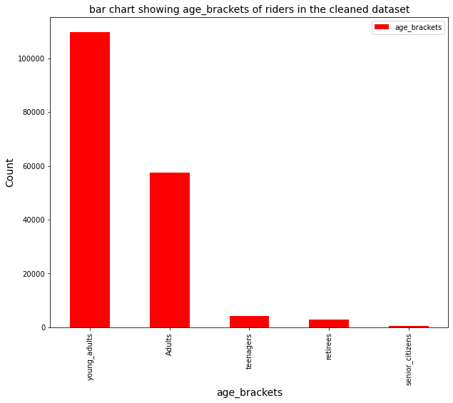

## Willingness to Share Bike for all Trip by Start Hour of the Day

The countplot comparing starts hours by willingness to share bike for al trip is multimodal. Gokike riders are vocal about not sharing a bike for all trip regardless of the hour of the day for trip commencement.

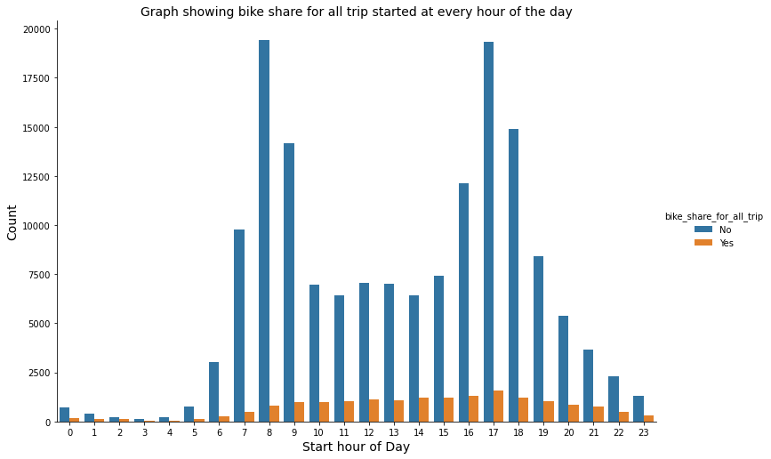

## Average Duration of Trips Undertaken by User Types on Start Days of the Week

The pointplot comparing average duration of trips by user types and starts days is sinusodial. Casual user approach and weekend trips may pass as recipes for longer rides.

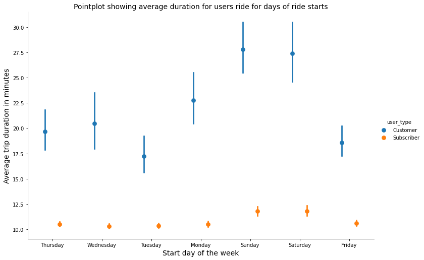

## Average Duration of Trips Undertaken by Gender on Start Days of the Week

The pointplot comparing average duration of trips by gender and starts days is sinusodial. Weekends are prefered for starting longer trip for all genders but other gender identifications travels for longer on the average.

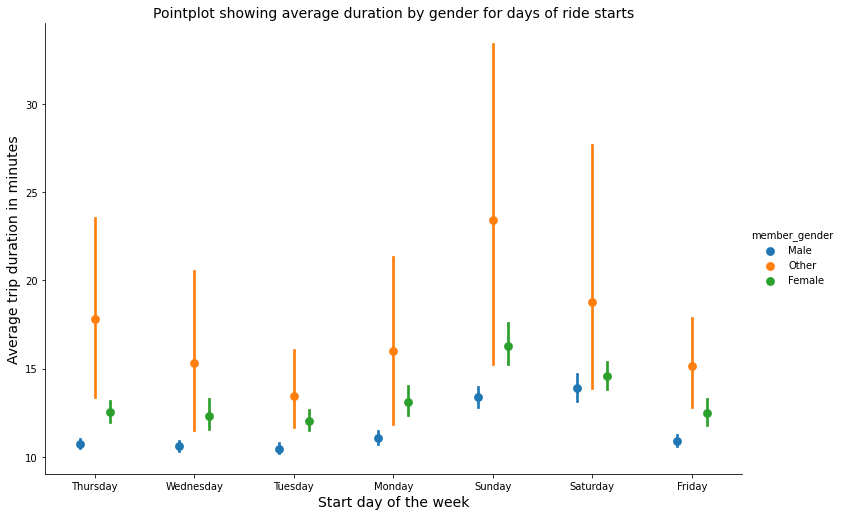